# Průzkumná analýza dat

Kateřina Večerková vecerkok@vscht.cz

2025-06-26

# Průzkumná analýza dat (EDA)

## **1. Co je Průzkumná analýza dat (EDA)?**

- **Definice**: EDA je první krok v analýze dat, který slouží k souhrnu jejich hlavních charakteristik, často pomocí vizualizačních metod.
- **Účel**: Porozumět struktuře dat, odhalit odlehlé hodnoty nebo anomálie, rozpoznat vzorce a generovat hypotézy.
- **Důležitost**: Před prováděním složitějších statistických analýz pomáhá EDA ověřit kvalitu dat a odhalit předpoklady, které mohou ovlivnit další fáze analýzy.

## **2. Kroky v rámci EDA**

### 1. **Porozumění typům a struktuře dat**

- **Typy dat**: Kategorická (nominální, ordinální) vs. Numerická (kontinuální, diskrétní).
- **Datové struktury v R**: Základní znalosti o `data.frame`, `factors`, `lists` a numerických typech (`integers`, `doubles`).

```r
# Načtení a zobrazení struktury dat
data <- read.csv("titanic.csv")
str(data)
```

```
## 'data.frame':    891 obs. of  12 variables:
##  $ PassengerId: int  1 2 3 4 5 6 7 8 9 10 ...
##  $ Survived   : int  0 1 1 1 0 0 0 0 1 1 ...
##  $ Pclass     : int  3 1 3 1 3 3 1 3 3 2 ...
##  $ Name       : chr  "Braund, Mr. Owen Harris" "Cumings, Mrs. John Bradley (Florence Briggs Thayer)" "Heikkinen, Miss. Laina" "Futrelle, Mrs. Jacques Heath (Lily May Peel)" ...
##  $ Sex        : chr  "male" "female" "female" "female" ...
##  $ Age        : num  22 38 26 35 35 NA 54 2 27 14 ...
##  $ SibSp      : int  1 1 0 1 0 0 0 3 0 1 ...
##  $ Parch      : int  0 0 0 0 0 0 0 1 2 0 ...
##  $ Ticket     : chr  "A/5 21171" "PC 17599" "STON/O2. 3101282" "113803" ...
##  $ Fare       : num  7.25 71.28 7.92 53.1 8.05 ...
##  $ Cabin      : chr  "" "C85" "" "C123" ...
##  $ Embarked   : chr  "S" "C" "S" "S" ...
```

```r
summary(data)
```

```
##   PassengerId       Survived          Pclass          Name
##  Min.   :  1.0   Min.   :0.0000   Min.   :1.000   Length:891
##  1st Qu.:223.5   1st Qu.:0.0000   1st Qu.:2.000   Class :character
##  Median :446.0   Median :0.0000   Median :3.000   Mode  :character
##  Mean   :446.0   Mean   :0.3838   Mean   :2.309
##  3rd Qu.:668.5   3rd Qu.:1.0000   3rd Qu.:3.000
##  Max.   :891.0   Max.   :1.0000   Max.   :3.000
##
##      Sex                 Age            SibSp           Parch
##  Length:891         Min.   : 0.42   Min.   :0.000   Min.   :0.0000
##  Class :character   1st Qu.:20.12   1st Qu.:0.000   1st Qu.:0.0000
##  Mode  :character   Median :28.00   Median :0.000   Median :0.0000
##                     Mean   :29.70   Mean   :0.523   Mean   :0.3816
##                     3rd Qu.:38.00   3rd Qu.:1.000   3rd Qu.:0.0000
##                     Max.   :80.00   Max.   :8.000   Max.   :6.0000
##                     NA's   :177
##     Ticket               Fare           Cabin             Embarked
##  Length:891         Min.   :  0.00   Length:891         Length:891
##  Class :character   1st Qu.:  7.91   Class :character   Class :character
##  Mode  :character   Median : 14.45   Mode  :character   Mode  :character
##                     Mean   : 32.20
##                     3rd Qu.: 31.00
##                     Max.   :512.33
##
```

### 2. **Souhrnné statistiky**

#### - **Numerické proměnné**:

- Průměr, medián, směrodatná odchylka, rozsah, minimum, maximum, kvartily.
- Užitečné funkce: `mean()`, `median()`, `sd()`, `range()`, `summary()`.

```r
# Souhrnné statistiky
summary(data$Fare)
```

```
##    Min. 1st Qu.  Median    Mean 3rd Qu.    Max.
##    0.00    7.91   14.45   32.20   31.00  512.33
```

```r
mean(data$Fare, na.rm = TRUE)
```

```
## [1] 32.20421
```

#### - **Kategorické proměnné**:

- Počty výskytů a proporce.
- Užitečné funkce: `table()`, `prop.table()`.

```r
# Frekvenční tabulka
table(data$Cabin)
```

```
##
##                             A10             A14             A16             A19
##             687               1               1               1               1
##             A20             A23             A24             A26             A31
##               1               1               1               1               1
##             A32             A34             A36              A5              A6
##               1               1               1               1               1
##              A7            B101            B102             B18             B19
##               1               1               1               2               1
##             B20             B22             B28              B3             B30
##               2               2               2               1               1
##             B35             B37             B38             B39              B4
##               2               1               1               1               1
##             B41             B42             B49              B5             B50
##               1               1               2               2               1
##     B51 B53 B55 B57 B59 B63 B66         B58 B60             B69             B71
##               2               2               2               1               1
##             B73             B77             B78             B79             B80
##               1               2               1               1               1
##         B82 B84             B86             B94         B96 B98            C101
##               1               1               1               4               1
##            C103            C104            C106            C110            C111
##               1               1               1               1               1
##            C118            C123            C124            C125            C126
##               1               2               2               2               2
##            C128            C148              C2         C22 C26     C23 C25 C27
##               1               1               2               3               4
##             C30             C32             C45             C46             C47
##               1               1               1               1               1
##             C49             C50             C52             C54         C62 C64
##               1               1               2               1               1
##             C65             C68              C7             C70             C78
##               2               2               1               1               2
##             C82             C83             C85             C86             C87
##               1               2               1               1               1
##             C90             C91             C92             C93             C95
##               1               1               2               2               1
##             C99               D         D10 D12             D11             D15
##               1               3               1               1               1
##             D17             D19             D20             D21             D26
##               2               1               2               1               2
##             D28             D30             D33             D35             D36
##               1               1               2               2               2
##             D37             D45             D46             D47             D48
##               1               1               1               1               1
##             D49             D50             D56              D6              D7
##               1               1               1               1               1
##              D9             E10            E101             E12            E121
##               1               1               3               1               2
##             E17             E24             E25             E31             E33
##               1               2               2               1               2
##             E34             E36             E38             E40             E44
##               1               1               1               1               2
##             E46             E49             E50             E58             E63
##               1               1               1               1               1
##             E67             E68             E77              E8           F E69
##               2               1               1               2               1
##           F G63           F G73              F2             F33             F38
##               1               2               3               3               1
##              F4              G6               T
##               2               4               1
```

### 3. **Vizualizační techniky**

#### - **Histogram**: Vizualizuje rozložení jedné spojité proměnné.

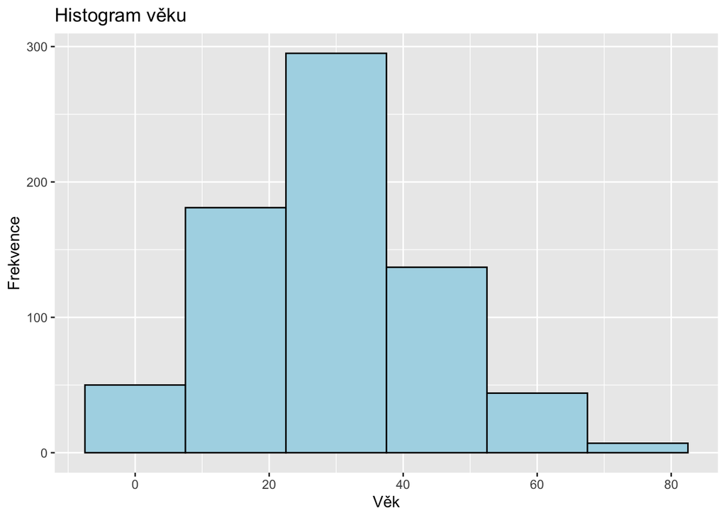

```r
library(ggplot2)

ggplot(data, aes(x = Age)) +
  geom_histogram(binwidth = 15, fill = "lightblue", color = "black") +
  labs(title = "Histogram věku", x = "Věk", y = "Frekvence")
```

#### - **Boxplot (krabicový graf)**: Zobrazuje rozložení, střední hodnotu a možné odlehlé hodnoty, často podle kategorií.

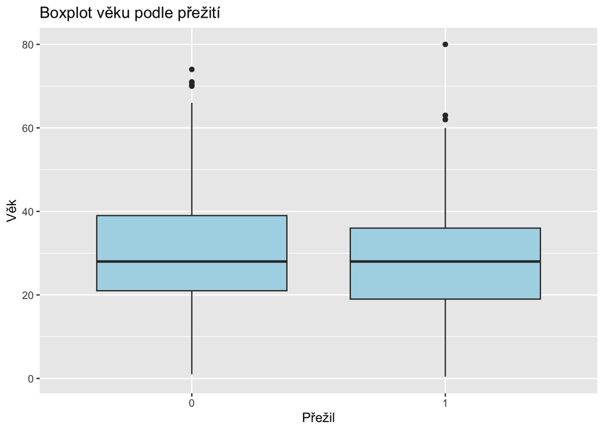

```r
ggplot(data, aes(x = factor(Survived), y = Age)) +
  geom_boxplot(fill = "lightblue") +
  labs(title = "Boxplot věku podle přežití", x = "Přežil", y = "Věk")
```

#### - **Sloupcový graf**: Zobrazuje frekvence kategoriálních proměnných.

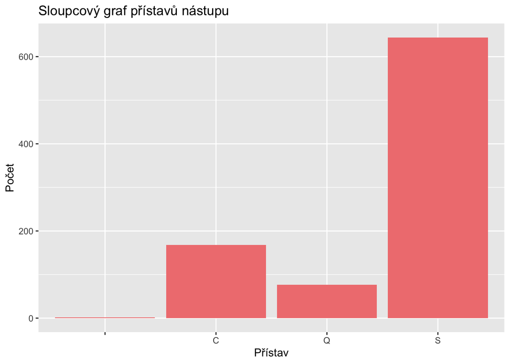

```r
ggplot(data, aes(x = Embarked)) +
  geom_bar(fill = "lightcoral") +
  labs(title = "Sloupcový graf přístavů nástupu", x = "Přístav", y = "Počet")
```

#### - **Bodový graf**: Ukazuje vztah mezi dvěma spojitými proměnnými.

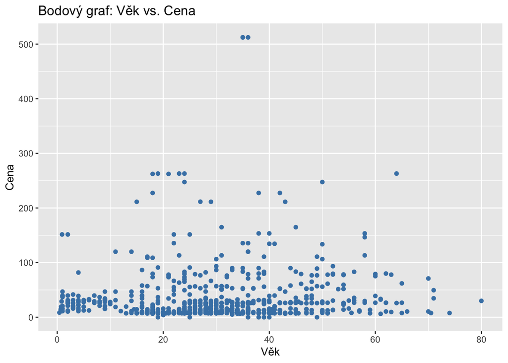

```r
ggplot(data, aes(x = Age, y = Fare)) +
  geom_point(color = "steelblue") +
  labs(title = "Bodový graf: Věk vs. Cena", x = "Věk", y = "Cena")
```

### 4. **Detekce odlehlých hodnot**

- **Odlehlé hodnoty**: Hodnoty, které se výrazně liší od ostatních v datové sadě.
- **Metody identifikace**: Boxploty, z-skóre (standardizace), metoda IQR.

```r
# Identifikace odlehlých hodnot pomocí IQR
Q1 <- quantile(data$Age, 0.25, na.rm=TRUE)
Q3 <- quantile(data$Age, 0.75, na.rm=TRUE)
IQR <- Q3 - Q1
outliers <- data$Age[data$Age < (Q1 - 1.5 * IQR) | data$Age > (Q3 + 1.5 * IQR)]
outliers <- outliers[!is.na(outliers)] # odstranění NA
outliers
```

```
##  [1] 66.0 65.0 71.0 70.5 65.0 65.0 71.0 80.0 70.0 70.0 74.0
```

### 5. **Zpracování chybějících hodnot**

- **Zjištění chybějících hodnot**: Zkontrolujte přítomnost a rozsah chybějících hodnot.

```r
# Kontrola chybějících hodnot
colSums(is.na(data))
```

```
## PassengerId    Survived      Pclass        Name         Sex         Age
##           0           0           0           0           0         177
##       SibSp       Parch      Ticket        Fare       Cabin    Embarked
##           0           0           0           0           0           0
```

- **Zpracování chybějících hodnot**: Obvyklé přístupy zahrnují odstranění nebo imputaci (průměrem / mediánem).

### 6. **Zkoumání vztahů mezi proměnnými**

#### - **Korelační matice**: Ukazuje lineární vztahy mezi páry spojitých proměnných.

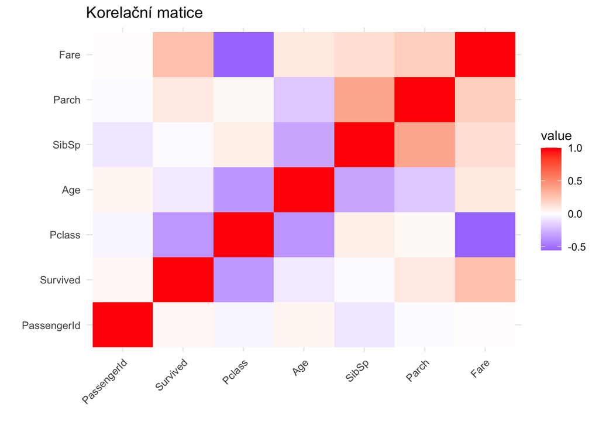

```r
library(reshape2)
cor_matrix <- cor(data[, sapply(data, is.numeric)], use = "complete.obs")
cor_data <- melt(cor_matrix)

ggplot(cor_data, aes(x = Var1, y = Var2, fill = value)) +
  geom_tile() +
  scale_fill_gradient2(low = "blue", mid = "white", high = "red", midpoint = 0) +
  labs(title = "Korelační matice", x = "", y = "") +
  theme_minimal() +
  theme(axis.text.x = element_text(angle = 45, hjust = 1))
```

#### - **Kontingenční tabulka**: Analyzuje vztah mezi dvěma kategoriálními proměnnými.

```r
# Kontingenční tabulka
table(data$Survived, data$Sex)
```

```
##
##     female male
##   0     81  468
##   1    233  109
```

#### - **Analýza hlavních komponent (PCA)**:

PCA je metoda redukce dimenzionality, která transformuje data na sadu ortogonálních komponent zachycujících největší variabilitu. Umožňuje zjednodušení dat, odhalení struktur a vizualizaci ve 2D/3D prostoru.

```r
library(dplyr)
library(magrittr)

# Výběr numerických sloupců pro PCA
numeric_columns <- data %>%
  dplyr::select(Age, Fare, SibSp, Parch, Survived) %>%
  na.omit()  # odstranění chybějících hodnot

# provedení PCA
pca_result <- prcomp(numeric_columns, scale. = TRUE)
pca_scores <- as.data.frame(pca_result$x)

# přidání sloupce přežití
pca_scores$survived <- numeric_columns$Survived
```

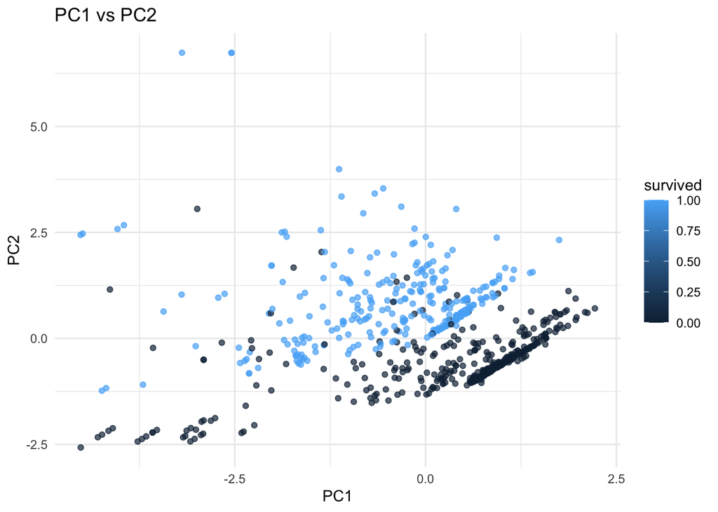

```r
ggplot(pca_scores, aes(x = PC1, y = PC2)) +
  geom_point(alpha = 0.7, aes(color = survived)) +
  labs(title = "PC1 vs PC2", x = "PC1", y = "PC2") +
  theme_minimal()
```

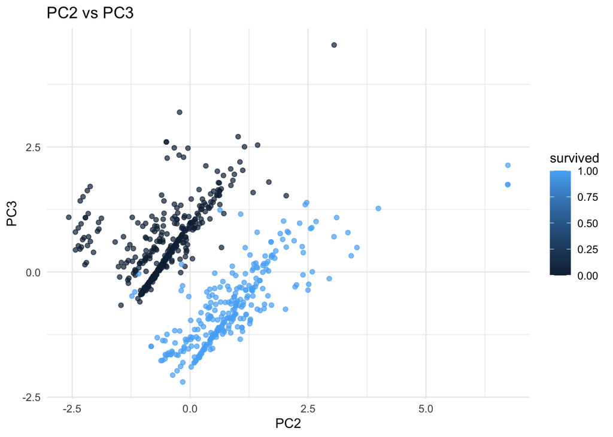

```r
ggplot(pca_scores, aes(x = PC2, y = PC3)) +
  geom_point(alpha = 0.7, aes(color = survived)) +
  labs(title = "PC2 vs PC3", x = "PC2", y = "PC3") +
  theme_minimal()
```

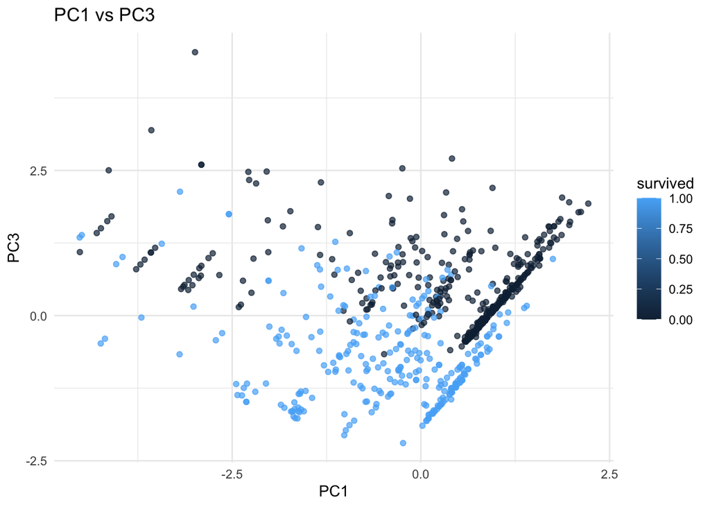

```r
ggplot(pca_scores, aes(x = PC1, y = PC3)) +
  geom_point(alpha = 0.7, aes(color = survived)) +
  labs(title = "PC1 vs PC3", x = "PC1", y = "PC3") +
  theme_minimal()
```

## **3. Klíčové poznatky a další kroky**

- **Shrnutí zjištění**: Stručně popište hlavní poznatky, neobvyklé vzory nebo problémy (např. šikmost, velké množství chybějících hodnot).
- **Generování hypotéz**: Na základě EDA navrhněte možné hypotézy nebo otázky pro další analýzu.